# google real data

Anthony working away

```r
#google realtime data
# devtools::install_github("ipeaGIT/gtfs2gps", lib = "C:/Program Files/R/R-3.6.2/library")
library(gtfs2gps)
```

# `gtfs2gps`

Converting GTFS data to GPS-like format. Rafael H. M. Pereira, Pedro R. Andrade, Joao Bazzo

15 December 2019

# Introduction

Package `gtfs2gps` allows users to convert public transport GTFS data into a single `data.table` format with GPS-like records, which can then be used in various applications such as running transport simulations or scenario analyses. Before using the package, just install it from GitHub.

```r
# devtools::install_github("ipeaGIT/gtfs2gps")
```

# Loading data

After loading the package, GTFS data can be read into R by using `read_gtfs()`. This function gets a zipped GTFS file and returns a list of `data.table` objects. The returning list contains the data of each GTFS file indexed according to their file names without extension.

```r
library("gtfs2gps")
sao <- read_gtfs(system.file("extdata/saopaulo.zip", package ="gtfs2gps"))
names(sao)
```

```
## [1] "agency"      "routes"      "stops"       "stop_times"  "shapes"
## [6] "trips"       "calendar"    "frequencies"
```

```r
sao$trips
```

```
##      route_id service_id   trip_id    trip_headsign direction_id shape_id
##   1:  121G-10        USD 121G-10-0   Metrô Tucuruvi            0    52421
##   2:  148L-10        USD 148L-10-0             Lapa            0    52857
##   3:  148L-10        USD 148L-10-1  Cohab Antártica            1    52858
##   4:  1720-10        USD 1720-10-0       Cantareira            0    54502
##   5:  1720-10        USD 1720-10-1       Jd. Guancã            1    54503
##  ---
## 229:  N732-11        USD N732-11-0 Term. Jd. Jacira            0    51990
## 230:  N739-11        USD N739-11-0    Jd. Universal            0    51954
## 231:  N740-11        USD N740-11-0      Jd. Riviera            0    51939
## 232:  N838-11        USD N838-11-0  Cptm Leopoldina            0    52072
## 233:  N840-11        USD N840-11-0     Sta. Cecília            0    52135
```

Note that not all GTFS files are loaded into R. This function only loads the necessary data to spatially and temporally handle trips and stops, which are: - agency.txt - calendar.txt - routes.txt - shapes.txt - stop_times.txt - stops.txt - trips.txt - frequencies.txt (this last one is optional).

If a given GTFS zipped file does not contain all of these required files then `read_gtfs()` will stop with an error.

# Subsetting GTFS Data

GTFS data sets can be fairly large for complex public transport networks and, in some cases, users might want to focus on specific transport services at week days/weekends, or on specific trips or routes. The package brings some functions to filter GTFS.zip and speed up the data processing.

```r
library(magrittr)
object.size(sao) %>% format(units = "Kb")
```

```
## [1] "5419.4 Kb"
```

```r
sao_small <- gtfs2gps::filter_by_shape_id(sao, c(51338, 51956, 51657))
object.size(sao_small) %>% format(units = "Kb")
```

```
## [1] "88.5 Kb"
```

We can then easily convert the data to simple feature format and plot them.

```r
sao_small_shapes_sf <- gtfs2gps::gtfs_shapes_as_sf(sao_small)
```

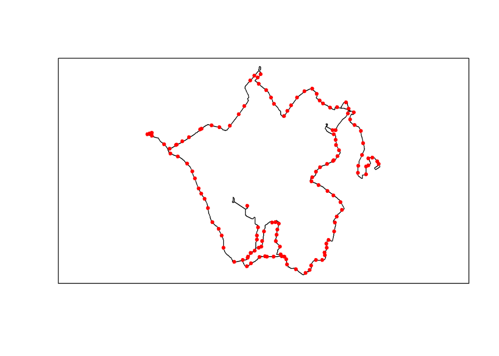

[figure not shown]

```r
sao_small_stops_sf <- gtfs2gps::gtfs_stops_as_sf(sao_small)
plot(sf::st_geometry(sao_small_shapes_sf))
plot(sf::st_geometry(sao_small_stops_sf), pch = 20, col = "red", add = TRUE)
box()
```

After subsetting the data, it is also possible to save it as a new GTFS file using `write_gtfs()`, as shown below.

```r
# file.copy(paste0(tempd, "/result.zip"), file, overwrite = TRUE)
# write_gtfs(sao_small)
```

# Converting to GPS-like format

To convert GTFS to GPS-like format, use `gtfs2gps()`. This is the core function of the package. It takes a GTFS zipped file as an input and returns a `data.table` where each row represents a ‘GPS-like’ data point for every trip in the GTFS file. In summary, this function interpolates the space-time position of each vehicle in each trip considering the network distance and average speed between stops. The function samples the timestamp of each vehicle every $15m$ by default, but the user can set a different value in the `spatial_resolution` argument. See the example below.

```r
sao_gps <- gtfs2gps(gtfs_data = sao_small, progress = TRUE, cores = 1, spatial_resolution = 15)
```

```
## converting shapes to sf objects
```

```
## Processing the data
```

```
## Using 1 CPU core
```

```
## 5010-10-0
```

```
## 5018-31-1
```

```
## 5024-31-0
```

```r
head(sao_gps)
```

```
##      trip_id route_type id shape_pt_lon shape_pt_lat departure_time stop_id
## 1: 5010-10-0          3  1    -46.63120    -23.66268       04:00:01 3703053
## 2: 5010-10-0          3  2    -46.63117    -23.66273       04:00:02      NA
## 3: 5010-10-0          3  3    -46.63113    -23.66281       04:00:04      NA
## 4: 5010-10-0          3  4    -46.63108    -23.66288       04:00:05      NA
## 5: 5010-10-0          3  5    -46.63103    -23.66299       04:00:07      NA
## 6: 5010-10-0          3  6    -46.63098    -23.66311       04:00:09      NA
##    stop_sequence      dist   cumdist    speed   cumtime shape_id
## 1:             1  7.230445  7.230445 26.11298 0.9968071    51338
## 2:            NA  9.184637 16.415083 26.11298 2.2630239    51338
## 3:            NA  9.184637 25.599720 26.11298 3.5292407    51338
## 4:            NA 13.802386 39.402106 26.11298 5.4320717    51338
## 5:            NA 13.802386 53.204492 26.11298 7.3349028    51338
## 6:            NA 13.802386 67.006878 26.11298 9.2377339    51338
```

The following figure maps the first 100 data points of the sample data we processed.

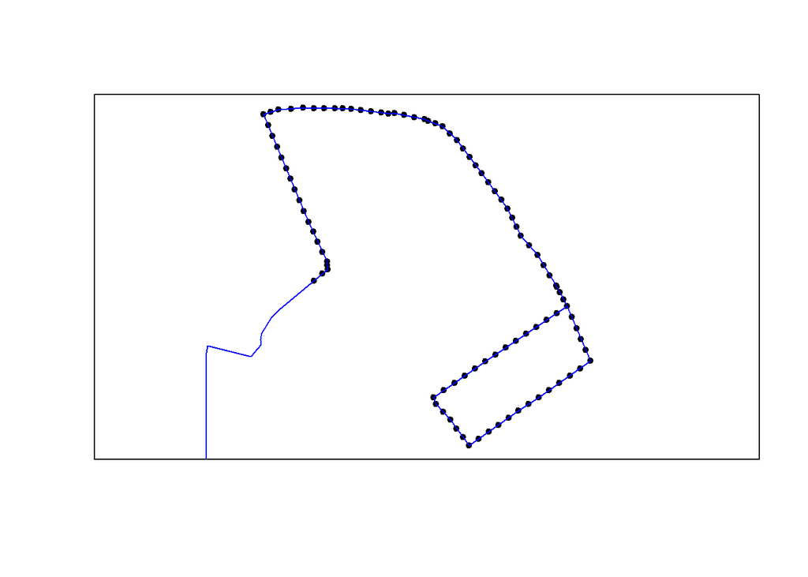

[figure not shown]

```r
shapes_sf <- gps_as_sf(sao_gps)
sao_gps60 <- sao_gps[1:100, ]
sao_gps60_sf <- gps_as_sf(sao_gps60)
plot(sf::st_geometry(sao_gps60_sf), pch = 20)
plot(sf::st_geometry(sao_small_shapes_sf), col = "blue", add = TRUE)
box()
```

The function `gtfs2gps()` automatically recognises whether the GTFS data brings detailed `stop_times.txt` information or whether it is a `frequency.txt` GTFS file. A sample data of a GTFS with detailed `stop_times.txt` cab be found below:

```r
poa <- system.file("extdata/poa.zip", package ="gtfs2gps")
poa_gps <- gtfs2gps(poa, progress = FALSE)
```

```
## Unzipping and reading GTFS.zip file
```

```
## converting shapes to sf objects
```

```
## Processing the data
```

```
## Using 7 CPU cores
```

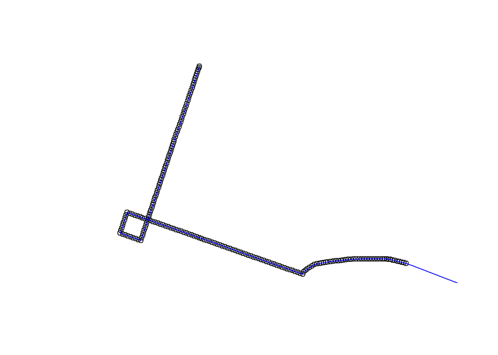

[figure not shown]

```r
poa_gps_sf <- gps_as_sf(poa_gps)
poa_sf <- read_gtfs(poa) %>% gtfs_shapes_as_sf()
plot(sf::st_geometry(poa_gps_sf[1:200,]))
plot(sf::st_geometry(poa_sf), col = "blue", add = TRUE)
```

## Methodological note

For a given trip, the function `gtfs2gps` calculates the average speed between each pair of stops — given by the ratio between cumulative network distance `S` and departure time `t` for a consecutive pair of valid stop_ids (`i`),

[figure not shown]

Since the beginning of each trip usually starts before the first stop_id, the mean speed cannot be calculated as shown in the previous equation because information on `i` period does not exist. In this case, the function consider the mean speed for the whole trip. It also happens after the last valid stop_id (`N`) of the trips, where info on `i+1` also does not exist.

[figure not shown]

## Final remarks

If you have any suggestions or want to report an error, please visit the GitHub page of the package [here](https://github.com/ipeaGIT/gtfs2gps).